## Group 61

### Yuwen Guan, Yi Le, Yunwan Zhang, Zihan Mo

# 1. Project Background

## 1.1 Project goal:

#### Predict the Delayed Status of the Flights Depart from SFO

## 1.2 Data sources :

### a. Flights Dataset: United States Department of Transportation

##### Data size: 2.12G

##### Description: Monthly flights of the United States from 2013 to 2015

##### For this project, around 500,000 flights departure from San Francisco International Airport (SFO) are extracted.

### b. Historical Hourly Weather Data 2012-2017: Kaggle

#### Data size: 52.5MB

#### Description: Hourly weather data for 30 US & Canadian Cities + 6 Israeli Cities

#### For this project, weather conditions in SF from 2013 to 2015 are extracted.

# 2. Data extraction and Munging

#### SFO:

#### a. Extract SFO data from 2013 to 2015

#### b. Drop NA records regarding DEP_DELAY and CANCELLED: 1.9% of the original records are dropped

#### c. Transform the departure time to a categorical variable: “HOUR”

#### d. Derive a new variable "HDAYS": number of days to the nearest holiday

#### e. Define the DELAY status as more than 15 mins late: “DELAY_FLAG”

#### Weather:

#### a. Combine humidity, temprature, wind_speed, and weather description data, then only use records related to SFO

#### b. Since humidity, temperature, and wind_speed are recorded several times a day, we use mean to represent a corresponding day

#### c. Rank weather description from 1-3 corresponding to normal, bad, and terrible

#### SFO Variables Clarifications

- **YEAR**: 2013-2015
- **MONTH**: 1-12(JAN-DEC)
- **DAY_OF_WEEK**: 1-7(MON-SUN)
- **OP_UNIQUE_CARRIER**: Airline
- **ORIGIN**: Departure airport
- **DEST**: Arrival airport
- **CRS_DEP_TIME**: Scheduled departure time (first 2 digits are hour, last 2 digits are minute)
- **CANCELLED**: If the flight is cancelled (YES=1)
- **DEP_DELAY**: Departure delay in minute
- **CARRIER_DELAY**: Delay due to airline operation
- **WEATHER_DELAY**: Delay due to unsatisfactory weather
- **NAS_DELAY**: Delay that is within the control of the National Airspace System (NAS) may include: non-extreme weather conditions, airport operations, heavy traffic volume, air traffic control, etc
- **SECURITY_DELAY**: Delay due to secruity issue
- **LATE_AIRCRAFT_DELAY**: Delay due to late arrival aircraft

**Final dataset would be like:**

```python
import pandas as pd
sfo = pd.read_csv('full_df.csv')
sfo = sfo[['DELAY_FLAG','WEATHER', 'YEAR','MONTH', 'OP_UNIQUE_CARRIER','DAY_OF_WEEK', 'DEST', 'DISTANCE', 'HOUR', 'HDAYS',
               'HUMIDITY', 'TEMPERATURE', 'WIND_SPEED']]
sfo.head(10)
```

|  | DELAY_FLAG | WEATHER | YEAR | MONTH | OP_UNIQUE_CARRIER | DAY_OF_WEEK | DEST | DISTANCE | HOUR | HDAYS | HUMIDITY | TEMPERATURE | WIND_SPEED |
| --- | --- | --- | --- | --- | --- | --- | --- | --- | --- | --- | --- | --- | --- |
| 0 | 0.0 | 1 | 2013 | 1 | F9 | 2 | DEN | 967 | 6 | 0 | 61.136364 | 279.84875 | 1.666667 |
| 1 | 0.0 | 1 | 2013 | 1 | F9 | 2 | DEN | 967 | 18 | 0 | 61.136364 | 279.84875 | 1.666667 |
| 2 | 0.0 | 1 | 2013 | 1 | F9 | 2 | DEN | 967 | 10 | 0 | 61.136364 | 279.84875 | 1.666667 |
| 3 | 0.0 | 1 | 2013 | 1 | F9 | 2 | DEN | 967 | 14 | 0 | 61.136364 | 279.84875 | 1.666667 |
| 4 | 1.0 | 1 | 2013 | 1 | FL | 2 | ATL | 2139 | 23 | 0 | 61.136364 | 279.84875 | 1.666667 |
| 5 | 0.0 | 1 | 2013 | 1 | FL | 2 | ATL | 2139 | 13 | 0 | 61.136364 | 279.84875 | 1.666667 |
| 6 | 0.0 | 1 | 2013 | 1 | FL | 2 | SNA | 372 | 7 | 0 | 61.136364 | 279.84875 | 1.666667 |
| 7 | 0.0 | 1 | 2013 | 1 | F9 | 2 | DEN | 967 | 8 | 0 | 61.136364 | 279.84875 | 1.666667 |
| 8 | 1.0 | 1 | 2013 | 1 | HA | 2 | HNL | 2399 | 9 | 0 | 61.136364 | 279.84875 | 1.666667 |
| 9 | 0.0 | 1 | 2013 | 1 | AA | 2 | MIA | 2585 | 21 | 0 | 61.136364 | 279.84875 | 1.666667 |

# 3. Data Statistics and Visualization

## 3.1 Geo Graph

#### A map displaying all airports' locations

```python
map = folium.Map(location=[37.6213, -122.3790],
                   #tiles='Cartodb Positron',
                   #marker_color='green'
                   zoom_start=4)
marker_cluster = folium.plugins.MarkerCluster().add_to(map)

lonlat = Air[['LONGITUDE','LATITUDE']].dropna()

for each in lonlat.iterrows():
    folium.Marker(
        location = [each[1]['LATITUDE'],each[1]['LONGITUDE']]
    ).add_to(marker_cluster)
    folium.plugins.MarkerCluster()

map
```

[interactive chart not shown]

#### A map displaying the total flight counts to each state

```python
state_geo = 'us-states.json'
state_data = Air.groupby('STATE')['AirCount'].sum().to_frame().reset_index()

m = folium.Map(location=[37.6213, -122.3790], zoom_start=3)

folium.Choropleth(
    geo_data=state_geo,
    name='choropleth',
    data=state_data,
    columns=['STATE', 'AirCount'],
    key_on='feature.id',
    fill_color='YlGn',
    fill_opacity=0.7,
    line_opacity=0.2,
    legend_name='Flights Count'
).add_to(m)

folium.LayerControl().add_to(m)
m
```

[interactive chart not shown]

#### Top five states with the most flights from SFO:

```python
state_data.sort_values(by=['AirCount'], ascending=False, na_position='first').head()
```

|  | STATE | AirCount |
| --- | --- | --- |
| 3 | CA | 140345 |
| 29 | TX | 37945 |
| 23 | NV | 30562 |
| 27 | OR | 29916 |
| 9 | IL | 26753 |

## 3.2 Number of Flights

### 3.2.1 Number of Flights vs Day of Week

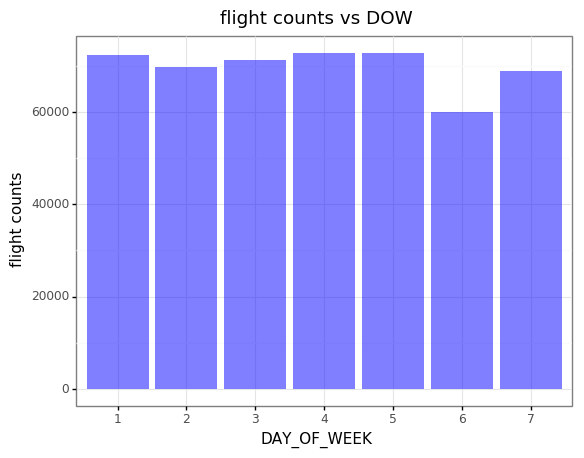

```python
p9.ggplot(nsfo, p9.aes(x='pd.Categorical(DAY_OF_WEEK)')) + p9.geom_col(stat='count',alpha=.5,fill='blue')\
+ p9.labels.ggtitle('flight counts vs DOW') + p9.ylab('flight counts') + p9.xlab('DAY_OF_WEEK')\
+ p9.theme_bw()
```

- **There are less flights on Saturday, while number of flights on other day of week are roughly the same**

### 3.2.2 Number of flights over Month

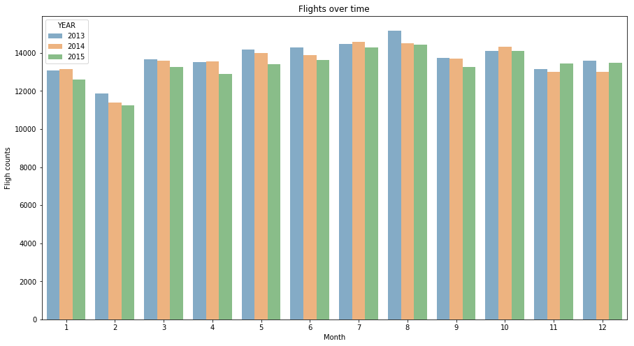

```python
plt.figure(figsize=(15,8))
sns.countplot(x='MONTH',hue='YEAR',alpha=.6,data=nsfo)
plt.xlabel('Month')
plt.ylabel('Fligh counts')
plt.title('Flights over time')
plt.show()
```

- **Trends of monthly flights for each year are similar, Febuary has the smallest traffic volumn, July/August has the largest traffic volumn**

## 3.3 Delayed Reasons Analysis

```python
df
```

|  | year | category | counts | proportion |
| --- | --- | --- | --- | --- |
| 0 | 2013 | CARRIER_DELAY | 17233 | 30.837643 |
| 1 | 2014 | CARRIER_DELAY | 20006 | 30.965206 |
| 2 | 2015 | CARRIER_DELAY | 16929 | 33.381973 |
| 3 | 2013 | WEATHER_DELAY | 883 | 1.580087 |
| 4 | 2014 | WEATHER_DELAY | 931 | 1.440998 |
| 5 | 2015 | WEATHER_DELAY | 894 | 1.762862 |
| 6 | 2013 | NAS_DELAY | 15147 | 27.104844 |
| 7 | 2014 | NAS_DELAY | 19138 | 29.621719 |
| 8 | 2015 | NAS_DELAY | 14716 | 29.018200 |
| 9 | 2013 | SECURITY_DELAY | 84 | 0.150314 |
| 10 | 2014 | SECURITY_DELAY | 73 | 0.112989 |
| 11 | 2015 | SECURITY_DELAY | 73 | 0.143947 |
| 12 | 2013 | LATE_AIRCRAFT_DELAY | 22536 | 40.327112 |
| 13 | 2014 | LATE_AIRCRAFT_DELAY | 24460 | 37.859089 |
| 14 | 2015 | LATE_AIRCRAFT_DELAY | 18101 | 35.693018 |

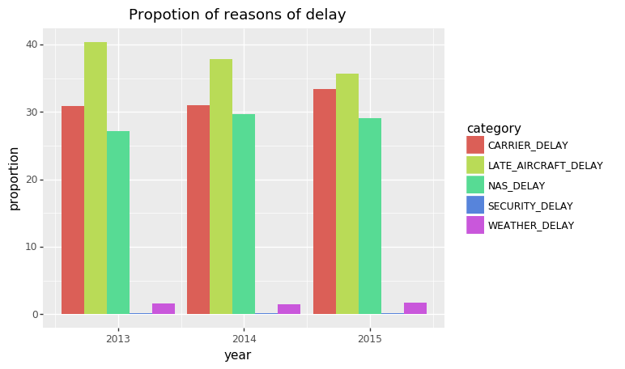

```python
ccolor = '#555555'

(p9.ggplot(df, p9.aes(x='year', y='proportion',fill='category'))
 + p9.geom_bar(stat='identity', position='dodge', show_legend=True)
 + p9.ggtitle('Propotion of reasons of delay')
)
```

From the figure, we can see that the most common reasons for the flight delay are **LATE_AIRCRAFT_DELAY, CARRIER_DELAY and NAS_DELAY**. Referring to variable clarification, non-extreme weather conditions and air traffic volumn are the reasons of **NAS_DELAY**. Therefore, although **WEATHER_DELAY** has very low proportion in the chart, we considered weather condition as a significant factor. Therefore, in the following steps, we explored how carriers, the total number of flights in a day, and weather condition affect the flights' delay status.

## 3.4 Delay Rate Analysis

### 3.4.1 Day of Week Statistics and Visualization

```python
dow_gby_d = sfo_delay[['YEAR','DAY_OF_WEEK','DEP_DELAY']].groupby(['YEAR','DAY_OF_WEEK'])
dow_gby = nsfo[['YEAR','DAY_OF_WEEK','DEP_DELAY']].groupby(['YEAR','DAY_OF_WEEK'])
dow_stat = groups_stat(dow_gby_d,dow_gby)
dow_stat.reset_index(inplace = True)
dow_stat.rename(columns={'level_0':'YEAR','level_1':'DAY_OF_WEEK'},inplace=True)
dow_stat
```

|  | YEAR | DAY_OF_WEEK | MAX_DEL | MIN_DEL | MEAN_DEL | MEDIAN_DEL | DELRT | TOT_COUNT |
| --- | --- | --- | --- | --- | --- | --- | --- | --- |
| 0 | 2013 | 1 | 1366.0 | 16.0 | 64.965812 | 48.0 | 0.235374 | 24357 |
| 1 | 2013 | 2 | 1174.0 | 16.0 | 64.138391 | 44.0 | 0.194200 | 23553 |
| 2 | 2013 | 3 | 609.0 | 16.0 | 60.684614 | 44.0 | 0.196348 | 23932 |
| 3 | 2013 | 4 | 550.0 | 16.0 | 61.608916 | 45.0 | 0.218346 | 24452 |
| 4 | 2013 | 5 | 1055.0 | 16.0 | 65.034667 | 46.0 | 0.220250 | 24622 |
| 5 | 2013 | 6 | 669.0 | 16.0 | 59.531401 | 40.0 | 0.181349 | 20546 |
| 6 | 2013 | 7 | 933.0 | 16.0 | 65.376581 | 46.0 | 0.223192 | 23379 |
| 7 | 2014 | 1 | 675.0 | 16.0 | 61.389736 | 45.0 | 0.243755 | 24221 |
| 8 | 2014 | 2 | 1302.0 | 16.0 | 60.968267 | 42.0 | 0.211979 | 23191 |
| 9 | 2014 | 3 | 1638.0 | 16.0 | 60.764111 | 43.0 | 0.241035 | 23814 |
| 10 | 2014 | 4 | 1249.0 | 16.0 | 59.483394 | 43.0 | 0.249090 | 24176 |
| 11 | 2014 | 5 | 1772.0 | 16.0 | 63.125060 | 45.0 | 0.257814 | 24316 |
| 12 | 2014 | 6 | 1342.0 | 16.0 | 58.357848 | 42.0 | 0.192227 | 20018 |
| 13 | 2014 | 7 | 1019.0 | 16.0 | 60.365704 | 41.0 | 0.219979 | 22984 |
| 14 | 2015 | 1 | 1496.0 | 16.0 | 65.374042 | 44.0 | 0.231589 | 23654 |
| 15 | 2015 | 2 | 1054.0 | 16.0 | 60.719583 | 42.0 | 0.186967 | 23079 |
| 16 | 2015 | 3 | 1365.0 | 16.0 | 57.138060 | 38.0 | 0.170918 | 23520 |
| 17 | 2015 | 4 | 1176.0 | 16.0 | 59.622018 | 41.0 | 0.212067 | 24115 |
| 18 | 2015 | 5 | 1036.0 | 16.0 | 63.660094 | 43.0 | 0.206438 | 23828 |
| 19 | 2015 | 6 | 1088.0 | 16.0 | 59.713748 | 39.0 | 0.136976 | 19383 |
| 20 | 2015 | 7 | 1209.0 | 16.0 | 64.003454 | 44.0 | 0.218863 | 22489 |

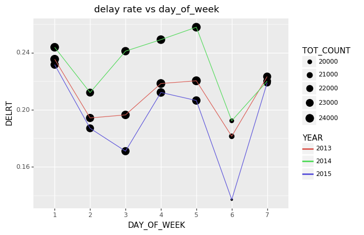

```python
p9.ggplot(dow_stat,p9.aes('pd.Categorical(DAY_OF_WEEK)','DELRT',group='YEAR'))+p9.geom_point(p9.aes(size='TOT_COUNT'))\
+ p9.geom_line(p9.aes(color = 'pd.Categorical(YEAR)'))\
+ p9.labs(x='DAY_OF_WEEK', color = 'YEAR', title = 'delay rate vs day_of_week')
```

1. **2013 and 2014 have same peaks and trough, while 2015's are slightly differnt**
2. **Apparently, higher day of week air traffic volumn has relatively higher delay rate**
3. **Therefore, we will explore further relation between total flights and day of week**

### 3.4.2 Daily Statistics and Visualization

```python
# #daily stat
day_gby_d = sfo_delay[['YEAR','DATE','DEP_DELAY']].groupby(['YEAR','DATE'])
day_gby = nsfo[['YEAR','DATE','DEP_DELAY']].groupby(['YEAR','DATE'])
day_stat = groups_stat(day_gby_d,day_gby)
day_stat.reset_index(inplace = True)
day_stat.rename(columns={'level_0':'YEAR','level_1':'DATE'},inplace=True)
day_stat
```

|  | YEAR | DATE | MAX_DEL | MIN_DEL | MEAN_DEL | MEDIAN_DEL | DELRT | TOT_COUNT |
| --- | --- | --- | --- | --- | --- | --- | --- | --- |
| 0 | 2013 | 2013-01-01 | 372.0 | 17.0 | 54.500000 | 31.0 | 0.103371 | 445 |
| 1 | 2013 | 2013-01-02 | 363.0 | 16.0 | 45.582090 | 31.0 | 0.137577 | 487 |
| 2 | 2013 | 2013-01-03 | 128.0 | 16.0 | 46.000000 | 33.0 | 0.071895 | 459 |
| 3 | 2013 | 2013-01-04 | 205.0 | 16.0 | 58.468085 | 34.0 | 0.101732 | 462 |
| 4 | 2013 | 2013-01-05 | 296.0 | 16.0 | 62.866667 | 39.0 | 0.236220 | 381 |
| 5 | 2013 | 2013-01-06 | 180.0 | 16.0 | 55.696970 | 39.5 | 0.150342 | 439 |
| 6 | 2013 | 2013-01-07 | 233.0 | 16.0 | 46.875000 | 32.0 | 0.109840 | 437 |
| 7 | 2013 | 2013-01-08 | 245.0 | 16.0 | 49.257143 | 28.0 | 0.087282 | 401 |
| 8 | 2013 | 2013-01-09 | 264.0 | 16.0 | 57.366667 | 46.0 | 0.291262 | 412 |
| 9 | 2013 | 2013-01-10 | 130.0 | 17.0 | 39.647059 | 29.0 | 0.113839 | 448 |
| 10 | 2013 | 2013-01-11 | 295.0 | 16.0 | 59.343750 | 39.5 | 0.143177 | 447 |
| 11 | 2013 | 2013-01-12 | 263.0 | 17.0 | 55.984848 | 38.0 | 0.190751 | 346 |
| 12 | 2013 | 2013-01-13 | 218.0 | 16.0 | 40.490741 | 30.5 | 0.253521 | 426 |
| 13 | 2013 | 2013-01-14 | 302.0 | 16.0 | 55.754902 | 44.5 | 0.240000 | 425 |
| 14 | 2013 | 2013-01-15 | 121.0 | 17.0 | 37.814815 | 29.0 | 0.068182 | 396 |
| 15 | 2013 | 2013-01-16 | 209.0 | 16.0 | 54.938776 | 41.0 | 0.119512 | 410 |
| 16 | 2013 | 2013-01-17 | 156.0 | 16.0 | 51.951220 | 28.0 | 0.093394 | 439 |
| 17 | 2013 | 2013-01-18 | 149.0 | 16.0 | 48.358974 | 39.0 | 0.086093 | 453 |
| 18 | 2013 | 2013-01-19 | 207.0 | 16.0 | 56.367347 | 47.0 | 0.138028 | 355 |
| 19 | 2013 | 2013-01-20 | 256.0 | 17.0 | 50.145161 | 32.0 | 0.147619 | 420 |
| 20 | 2013 | 2013-01-21 | 239.0 | 16.0 | 69.260870 | 40.5 | 0.107728 | 427 |
| 21 | 2013 | 2013-01-22 | 217.0 | 19.0 | 65.911765 | 51.5 | 0.084577 | 402 |
| 22 | 2013 | 2013-01-23 | 120.0 | 17.0 | 40.000000 | 27.0 | 0.050378 | 397 |
| 23 | 2013 | 2013-01-24 | 422.0 | 16.0 | 58.962963 | 39.0 | 0.184510 | 439 |
| 24 | 2013 | 2013-01-25 | 182.0 | 16.0 | 47.083333 | 35.0 | 0.216216 | 444 |
| 25 | 2013 | 2013-01-26 | 276.0 | 16.0 | 49.785714 | 29.0 | 0.160000 | 350 |
| 26 | 2013 | 2013-01-27 | 332.0 | 16.0 | 67.425532 | 33.0 | 0.110588 | 425 |
| 27 | 2013 | 2013-01-28 | 234.0 | 17.0 | 54.566038 | 34.0 | 0.123832 | 428 |
| 28 | 2013 | 2013-01-29 | 173.0 | 16.0 | 54.035714 | 48.5 | 0.069825 | 401 |
| 29 | 2013 | 2013-01-30 | 233.0 | 17.0 | 54.375000 | 43.0 | 0.097087 | 412 |
| ... | ... | ... | ... | ... | ... | ... | ... | ... |
| 1065 | 2015 | 2015-12-02 | 208.0 | 16.0 | 53.850000 | 40.5 | 0.133333 | 450 |
| 1066 | 2015 | 2015-12-03 | 460.0 | 16.0 | 87.402010 | 79.0 | 0.464953 | 428 |
| 1067 | 2015 | 2015-12-04 | 137.0 | 16.0 | 40.658537 | 35.0 | 0.089325 | 459 |
| 1068 | 2015 | 2015-12-05 | 222.0 | 16.0 | 60.703704 | 43.0 | 0.079646 | 339 |
| 1069 | 2015 | 2015-12-06 | 198.0 | 16.0 | 61.302198 | 54.5 | 0.427230 | 426 |
| 1070 | 2015 | 2015-12-07 | 762.0 | 16.0 | 61.091837 | 49.5 | 0.217295 | 451 |
| 1071 | 2015 | 2015-12-08 | 155.0 | 16.0 | 51.265823 | 41.0 | 0.184149 | 429 |
| 1072 | 2015 | 2015-12-09 | 240.0 | 16.0 | 42.190476 | 30.0 | 0.093541 | 449 |
| 1073 | 2015 | 2015-12-10 | 539.0 | 16.0 | 67.419162 | 44.0 | 0.364629 | 458 |
| 1074 | 2015 | 2015-12-11 | 221.0 | 16.0 | 52.320000 | 38.0 | 0.161638 | 464 |
| 1075 | 2015 | 2015-12-12 | 110.0 | 16.0 | 43.655172 | 28.0 | 0.085044 | 341 |
| 1076 | 2015 | 2015-12-13 | 1209.0 | 16.0 | 80.861905 | 58.0 | 0.508475 | 413 |
| 1077 | 2015 | 2015-12-14 | 688.0 | 17.0 | 71.196970 | 37.5 | 0.145374 | 454 |
| 1078 | 2015 | 2015-12-15 | 317.0 | 17.0 | 76.181818 | 52.0 | 0.150685 | 438 |
| 1079 | 2015 | 2015-12-16 | 255.0 | 16.0 | 50.061728 | 33.0 | 0.178022 | 455 |
| 1080 | 2015 | 2015-12-17 | 693.0 | 16.0 | 59.978495 | 36.0 | 0.194154 | 479 |
| 1081 | 2015 | 2015-12-18 | 1036.0 | 16.0 | 119.547244 | 100.0 | 0.582569 | 436 |
| 1082 | 2015 | 2015-12-19 | 1088.0 | 16.0 | 62.950704 | 37.0 | 0.327945 | 433 |
| 1083 | 2015 | 2015-12-20 | 508.0 | 16.0 | 94.791304 | 68.5 | 0.529954 | 434 |
| 1084 | 2015 | 2015-12-21 | 699.0 | 16.0 | 129.843137 | 113.5 | 0.723404 | 423 |
| 1085 | 2015 | 2015-12-22 | 559.0 | 16.0 | 76.866197 | 61.0 | 0.608137 | 467 |
| 1086 | 2015 | 2015-12-23 | 356.0 | 16.0 | 51.878205 | 34.5 | 0.320329 | 487 |
| 1087 | 2015 | 2015-12-24 | 208.0 | 16.0 | 45.896226 | 31.5 | 0.295265 | 359 |
| 1088 | 2015 | 2015-12-25 | 379.0 | 16.0 | 59.758621 | 42.0 | 0.154667 | 375 |
| 1089 | 2015 | 2015-12-26 | 912.0 | 16.0 | 62.555556 | 35.0 | 0.205011 | 439 |
| 1090 | 2015 | 2015-12-27 | 337.0 | 16.0 | 69.827225 | 53.0 | 0.417943 | 457 |
| 1091 | 2015 | 2015-12-28 | 1145.0 | 16.0 | 93.264151 | 49.0 | 0.347162 | 458 |
| 1092 | 2015 | 2015-12-29 | 389.0 | 16.0 | 77.248227 | 48.0 | 0.300640 | 469 |
| 1093 | 2015 | 2015-12-30 | 603.0 | 16.0 | 66.413793 | 39.0 | 0.367865 | 473 |
| 1094 | 2015 | 2015-12-31 | 394.0 | 16.0 | 62.872727 | 32.0 | 0.149051 | 369 |

1095 rows × 8 columns

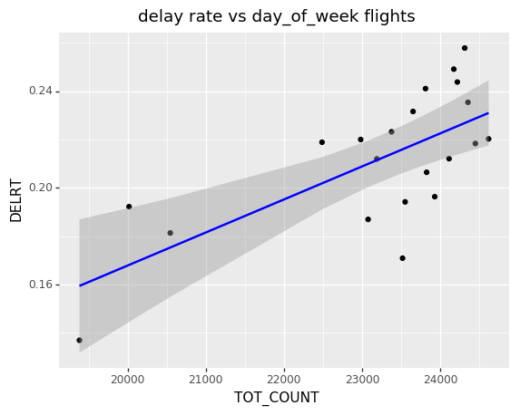

```python
# counts vs delay rate
p9.ggplot(dow_stat, p9.aes('TOT_COUNT', 'DELRT')) + p9.geom_point()\
+ p9.stat_smooth(method='lm', color='blue')\
+ p9.ggtitle('delay rate vs day_of_week flights')
```

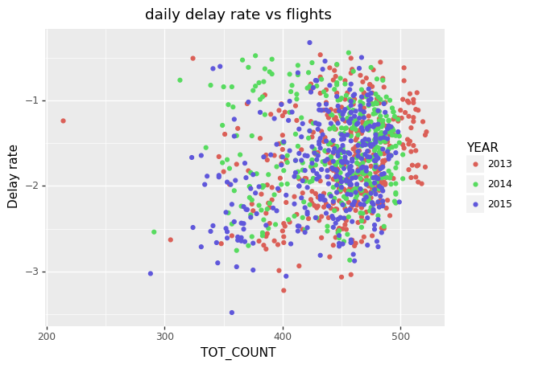

```python
# counts vs delay rate
p9.ggplot(day_stat, p9.aes('TOT_COUNT', 'np.log(DELRT)')) + p9.geom_point(p9.aes(color='pd.Categorical(YEAR)'))\
+ p9.labs(y='Delay rate', color = 'YEAR', title='daily delay rate vs flights')
```

- **Regarding the scatter plots above, day-of-week delay rate and flight counts have strong positive correlation. However, the population is very small so that it is not very persuasive**.
- **It's mroe clear on daily basis that delay rate does not flights change. Therefore, day_of_week flight count is more significant to the change of delay rate.**

### 3.4.3 Monthly Statistics and Visualization

```python
#monthly statistics
mon_gby_d = sfo_delay[['YEAR','MONTH','DEP_DELAY']].groupby(['YEAR','MONTH'])
mon_gby = nsfo[['YEAR','MONTH','DEP_DELAY']].groupby(['YEAR','MONTH'])
mon_stat = groups_stat(mon_gby_d,mon_gby).reset_index()
mon_stat.rename(columns={'level_0':'YEAR','level_1':'MONTH'},inplace=True)
mon_stat
```

|  | YEAR | MONTH | MAX_DEL | MIN_DEL | MEAN_DEL | MEDIAN_DEL | DELRT | TOT_COUNT |
| --- | --- | --- | --- | --- | --- | --- | --- | --- |
| 0 | 2013 | 1 | 422.0 | 16.0 | 53.098398 | 36.0 | 0.133834 | 13061 |
| 1 | 2013 | 2 | 734.0 | 16.0 | 57.194575 | 40.0 | 0.143050 | 11856 |
| 2 | 2013 | 3 | 594.0 | 16.0 | 62.628326 | 45.0 | 0.187006 | 13668 |
| 3 | 2013 | 4 | 1174.0 | 16.0 | 60.063887 | 43.0 | 0.219694 | 13537 |
| 4 | 2013 | 5 | 669.0 | 16.0 | 62.586244 | 46.0 | 0.198080 | 14166 |
| 5 | 2013 | 6 | 1366.0 | 16.0 | 72.029389 | 52.0 | 0.273694 | 14297 |
| 6 | 2013 | 7 | 639.0 | 16.0 | 73.548010 | 54.0 | 0.307219 | 14475 |
| 7 | 2013 | 8 | 1055.0 | 16.0 | 63.171633 | 48.0 | 0.293967 | 15182 |
| 8 | 2013 | 9 | 984.0 | 16.0 | 63.534179 | 47.0 | 0.206610 | 13736 |
| 9 | 2013 | 10 | 608.0 | 16.0 | 61.321772 | 43.0 | 0.169464 | 14121 |
| 10 | 2013 | 11 | 515.0 | 16.0 | 58.933204 | 41.0 | 0.157170 | 13145 |
| 11 | 2013 | 12 | 933.0 | 16.0 | 53.958393 | 36.5 | 0.206810 | 13597 |
| 12 | 2014 | 1 | 593.0 | 16.0 | 59.695295 | 42.0 | 0.203790 | 13141 |
| 13 | 2014 | 2 | 1638.0 | 16.0 | 67.774560 | 48.0 | 0.293540 | 11409 |
| 14 | 2014 | 3 | 447.0 | 16.0 | 57.252113 | 40.0 | 0.208808 | 13601 |
| 15 | 2014 | 4 | 1476.0 | 16.0 | 58.889807 | 41.0 | 0.187362 | 13562 |
| 16 | 2014 | 5 | 1342.0 | 16.0 | 55.987650 | 39.0 | 0.214214 | 13986 |
| 17 | 2014 | 6 | 1772.0 | 16.0 | 56.226558 | 40.0 | 0.265774 | 13884 |
| 18 | 2014 | 7 | 675.0 | 16.0 | 58.120363 | 43.0 | 0.249743 | 14571 |
| 19 | 2014 | 8 | 1166.0 | 16.0 | 57.496762 | 42.0 | 0.212614 | 14524 |
| 20 | 2014 | 9 | 620.0 | 16.0 | 55.534874 | 40.0 | 0.183139 | 13700 |
| 21 | 2014 | 10 | 599.0 | 16.0 | 58.319788 | 42.0 | 0.197419 | 14335 |
| 22 | 2014 | 11 | 404.0 | 16.0 | 62.208773 | 45.0 | 0.226231 | 13000 |
| 23 | 2014 | 12 | 1245.0 | 16.0 | 73.911044 | 52.0 | 0.357807 | 13007 |
| 24 | 2015 | 1 | 577.0 | 16.0 | 62.616241 | 44.0 | 0.192326 | 12614 |
| 25 | 2015 | 2 | 1365.0 | 16.0 | 66.814002 | 43.0 | 0.214979 | 11229 |
| 26 | 2015 | 3 | 1109.0 | 16.0 | 60.757174 | 41.0 | 0.170634 | 13274 |
| 27 | 2015 | 4 | 602.0 | 16.0 | 59.397045 | 42.0 | 0.167829 | 12906 |
| 28 | 2015 | 5 | 397.0 | 16.0 | 56.097935 | 41.0 | 0.223846 | 13411 |
| 29 | 2015 | 6 | 1496.0 | 16.0 | 60.745373 | 40.0 | 0.230221 | 13613 |
| 30 | 2015 | 7 | 1176.0 | 16.0 | 58.781269 | 41.0 | 0.234083 | 14277 |
| 31 | 2015 | 8 | 889.0 | 16.0 | 56.561445 | 41.0 | 0.205039 | 14446 |
| 32 | 2015 | 9 | 1126.0 | 16.0 | 54.195396 | 35.0 | 0.134293 | 13262 |
| 33 | 2015 | 10 | 505.0 | 16.0 | 58.428428 | 40.0 | 0.141046 | 14116 |
| 34 | 2015 | 11 | 1054.0 | 16.0 | 61.444171 | 39.0 | 0.151107 | 13454 |
| 35 | 2015 | 12 | 1209.0 | 16.0 | 77.153059 | 50.0 | 0.290138 | 13466 |

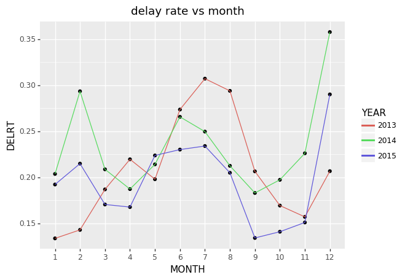

```python
p9.ggplot(mon_stat,p9.aes(x = 'pd.Categorical(MONTH)', y='DELRT',group='YEAR')) + p9.geom_point()\
+ p9.geom_line(p9.aes(color='pd.Categorical(YEAR)'))\
+ p9.labs(x='MONTH', color = 'YEAR')\
+ p9.ggtitle('delay rate vs month')
```

- **Delay rates over months have different peaks and troughs in different year. Therefore, year and month both affect delay rate.**

### 3.4.4 Airline Statistics and Visualization

```python
#Airlines statistics
al_gby_d = sfo_delay[['OP_UNIQUE_CARRIER','DEP_DELAY']].groupby('OP_UNIQUE_CARRIER')
al_gby = nsfo[['OP_UNIQUE_CARRIER','DEP_DELAY']].groupby('OP_UNIQUE_CARRIER')
al_stat = groups_stat(al_gby_d,al_gby).reset_index()
al_stat.rename(columns={'index':'airline'},inplace=True)
al_stat
```

|  | airline | MAX_DEL | MIN_DEL | MEAN_DEL | MEDIAN_DEL | DELRT | TOT_COUNT |
| --- | --- | --- | --- | --- | --- | --- | --- |
| 0 | AA | 1772.0 | 16.0 | 72.824040 | 44.0 | 0.185033 | 34891 |
| 1 | AS | 754.0 | 16.0 | 64.203500 | 47.0 | 0.164966 | 14894 |
| 2 | B6 | 603.0 | 16.0 | 63.325125 | 44.0 | 0.222840 | 13485 |
| 3 | DL | 797.0 | 16.0 | 61.498251 | 38.0 | 0.122583 | 27981 |
| 4 | F9 | 782.0 | 16.0 | 68.225929 | 45.0 | 0.259085 | 5091 |
| 5 | FL | 376.0 | 16.0 | 52.683824 | 37.0 | 0.239859 | 1134 |
| 6 | HA | 961.0 | 16.0 | 105.603175 | 39.5 | 0.084734 | 1487 |
| 7 | OO | 688.0 | 16.0 | 63.116136 | 48.0 | 0.241426 | 128325 |
| 8 | UA | 1088.0 | 16.0 | 59.546010 | 40.0 | 0.223528 | 150858 |
| 9 | US | 485.0 | 16.0 | 55.152667 | 38.0 | 0.112427 | 13342 |
| 10 | VX | 639.0 | 16.0 | 64.893852 | 46.0 | 0.155400 | 51287 |
| 11 | WN | 504.0 | 16.0 | 57.029242 | 42.0 | 0.282093 | 44854 |

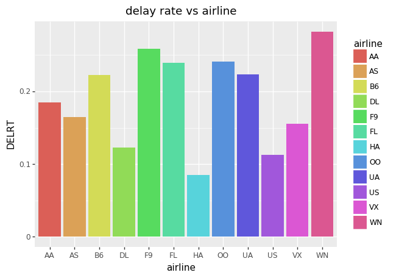

```python
p9.ggplot(al_stat,p9.aes('airline','DELRT',fill='airline'))+p9.geom_col()\
+ p9.ggtitle('delay rate vs airline')
```

- **South-West Airline has the highest delay rate, while Hawaiian Airline has the significantly lowest delay rate.**

### 3.4.5 Hourly Statistics and Visualization

```python
#hourly statistics
hour_gby_d = sfo_delay[['YEAR','HOUR','DEP_DELAY']].groupby(['YEAR','HOUR'])
hour_gby = nsfo[['YEAR','HOUR','DEP_DELAY']].groupby(['YEAR','HOUR'])
hour_stat = groups_stat(hour_gby_d,hour_gby)
hour_stat.reset_index(inplace = True)
hour_stat.rename(columns={'level_0':'YEAR','level_1':'HOUR'},inplace=True)
hour_stat
```

|  | YEAR | HOUR | MAX_DEL | MIN_DEL | MEAN_DEL | MEDIAN_DEL | DELRT | TOT_COUNT |
| --- | --- | --- | --- | --- | --- | --- | --- | --- |
| 0 | 2013 | 0 | 210.0 | 16.0 | 50.380952 | 36.0 | 0.158159 | 1195 |
| 1 | 2013 | 1 | 54.0 | 54.0 | 54.000000 | 54.0 | 0.500000 | 2 |
| 2 | 2013 | 10 | 587.0 | 16.0 | 62.743330 | 44.0 | 0.223387 | 13255 |
| 3 | 2013 | 11 | 1174.0 | 16.0 | 68.543651 | 49.0 | 0.268593 | 8444 |
| 4 | 2013 | 12 | 1055.0 | 16.0 | 67.356662 | 51.0 | 0.278799 | 10660 |
| 5 | 2013 | 13 | 564.0 | 16.0 | 62.720958 | 47.0 | 0.299864 | 10995 |
| 6 | 2013 | 14 | 933.0 | 16.0 | 62.460492 | 45.0 | 0.294800 | 9230 |
| 7 | 2013 | 15 | 427.0 | 16.0 | 62.069090 | 46.0 | 0.277262 | 10023 |
| 8 | 2013 | 16 | 518.0 | 16.0 | 62.414977 | 44.0 | 0.251102 | 10211 |
| 9 | 2013 | 17 | 375.0 | 16.0 | 59.775035 | 44.0 | 0.231661 | 6121 |
| 10 | 2013 | 18 | 494.0 | 16.0 | 61.006024 | 46.0 | 0.244357 | 6114 |
| 11 | 2013 | 19 | 400.0 | 16.0 | 62.858974 | 45.0 | 0.248521 | 8788 |
| 12 | 2013 | 20 | 756.0 | 16.0 | 65.184840 | 46.0 | 0.258909 | 5809 |
| 13 | 2013 | 21 | 801.0 | 16.0 | 70.649886 | 49.0 | 0.263306 | 4979 |
| 14 | 2013 | 22 | 796.0 | 16.0 | 60.408403 | 45.0 | 0.213429 | 9591 |
| 15 | 2013 | 23 | 984.0 | 16.0 | 57.770747 | 41.0 | 0.200374 | 4811 |
| 16 | 2013 | 5 | 657.0 | 16.0 | 88.640000 | 41.0 | 0.052743 | 948 |
| 17 | 2013 | 6 | 632.0 | 16.0 | 65.827206 | 43.0 | 0.055397 | 9820 |
| 18 | 2013 | 7 | 550.0 | 16.0 | 58.870162 | 35.0 | 0.073852 | 10846 |
| 19 | 2013 | 8 | 531.0 | 16.0 | 59.750979 | 40.0 | 0.101785 | 12546 |
| 20 | 2013 | 9 | 1366.0 | 16.0 | 64.696193 | 40.0 | 0.130680 | 10453 |
| 21 | 2014 | 0 | 349.0 | 16.0 | 42.693396 | 32.0 | 0.153179 | 1384 |
| 22 | 2014 | 1 | 20.0 | 18.0 | 19.000000 | 19.0 | 0.200000 | 10 |
| 23 | 2014 | 10 | 1302.0 | 16.0 | 62.284930 | 43.0 | 0.257603 | 12725 |
| 24 | 2014 | 11 | 1476.0 | 16.0 | 59.828286 | 42.0 | 0.293496 | 9564 |
| 25 | 2014 | 12 | 1019.0 | 16.0 | 61.996450 | 45.0 | 0.310334 | 9986 |
| 26 | 2014 | 13 | 466.0 | 16.0 | 58.995392 | 46.0 | 0.320420 | 11513 |
| 27 | 2014 | 14 | 1342.0 | 16.0 | 62.547247 | 45.5 | 0.332730 | 8842 |
| 28 | 2014 | 15 | 958.0 | 16.0 | 62.416174 | 44.5 | 0.315103 | 9654 |
| 29 | 2014 | 16 | 519.0 | 16.0 | 62.339687 | 46.0 | 0.302512 | 9712 |
| ... | ... | ... | ... | ... | ... | ... | ... | ... |
| 33 | 2014 | 20 | 407.0 | 16.0 | 63.778446 | 44.0 | 0.257392 | 7102 |
| 34 | 2014 | 21 | 740.0 | 16.0 | 57.594867 | 42.0 | 0.248916 | 4383 |
| 35 | 2014 | 22 | 636.0 | 16.0 | 50.446088 | 37.0 | 0.213247 | 9829 |
| 36 | 2014 | 23 | 677.0 | 16.0 | 53.056983 | 37.0 | 0.201986 | 4431 |
| 37 | 2014 | 5 | 215.0 | 16.0 | 53.191781 | 36.0 | 0.067468 | 1082 |
| 38 | 2014 | 6 | 399.0 | 16.0 | 58.734513 | 36.0 | 0.059947 | 9425 |
| 39 | 2014 | 7 | 1772.0 | 16.0 | 64.591781 | 38.0 | 0.071985 | 10141 |
| 40 | 2014 | 8 | 874.0 | 16.0 | 56.618513 | 36.0 | 0.111607 | 12777 |
| 41 | 2014 | 9 | 1638.0 | 16.0 | 64.016426 | 37.0 | 0.154911 | 9825 |
| 42 | 2015 | 0 | 539.0 | 16.0 | 57.500000 | 37.0 | 0.170499 | 1783 |
| 43 | 2015 | 1 | 699.0 | 16.0 | 94.250000 | 35.0 | 0.266667 | 45 |
| 44 | 2015 | 10 | 782.0 | 16.0 | 63.683994 | 44.0 | 0.245525 | 12850 |
| 45 | 2015 | 11 | 1365.0 | 16.0 | 62.324012 | 40.5 | 0.227163 | 9130 |
| 46 | 2015 | 12 | 1176.0 | 16.0 | 62.014563 | 43.0 | 0.249647 | 9902 |
| 47 | 2015 | 13 | 537.0 | 16.0 | 62.326319 | 43.0 | 0.268451 | 10799 |
| 48 | 2015 | 14 | 473.0 | 16.0 | 59.303848 | 42.0 | 0.261932 | 8632 |
| 49 | 2015 | 15 | 1145.0 | 16.0 | 62.032130 | 43.0 | 0.245331 | 8246 |
| 50 | 2015 | 16 | 1109.0 | 16.0 | 65.471259 | 44.0 | 0.230609 | 9128 |
| 51 | 2015 | 17 | 912.0 | 16.0 | 61.634451 | 42.0 | 0.226997 | 7749 |
| 52 | 2015 | 18 | 973.0 | 16.0 | 61.837354 | 45.0 | 0.239163 | 6067 |
| 53 | 2015 | 19 | 1036.0 | 16.0 | 60.824623 | 42.0 | 0.232955 | 7392 |
| 54 | 2015 | 20 | 773.0 | 16.0 | 64.020680 | 46.0 | 0.225889 | 6636 |
| 55 | 2015 | 21 | 508.0 | 16.0 | 59.503861 | 43.0 | 0.210057 | 4932 |
| 56 | 2015 | 22 | 559.0 | 16.0 | 51.614572 | 36.0 | 0.184492 | 10266 |
| 57 | 2015 | 23 | 741.0 | 16.0 | 56.200000 | 40.5 | 0.177502 | 4507 |
| 58 | 2015 | 5 | 1496.0 | 16.0 | 76.811111 | 37.5 | 0.051487 | 1748 |
| 59 | 2015 | 6 | 586.0 | 16.0 | 64.765182 | 39.0 | 0.061658 | 8012 |
| 60 | 2015 | 7 | 797.0 | 16.0 | 69.430213 | 40.0 | 0.070121 | 8685 |
| 61 | 2015 | 8 | 603.0 | 16.0 | 64.838831 | 38.0 | 0.101894 | 13092 |
| 62 | 2015 | 9 | 961.0 | 16.0 | 63.193007 | 37.0 | 0.136620 | 10467 |

63 rows × 8 columns

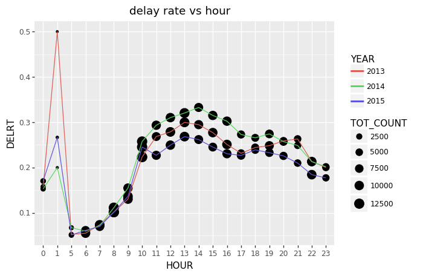

```python
p9.ggplot(hour_stat,p9.aes(x = 'pd.Categorical(HOUR.astype(int))', y='DELRT',group='YEAR'))\
+ p9.geom_point(p9.aes(size = 'TOT_COUNT'))\
+ p9.geom_line(p9.aes(color='pd.Categorical(YEAR)'))\
+ p9.labs(color = 'YEAR',x='HOUR')\
+ p9.ggtitle('delay rate vs hour')
```

1. Since the number flights at 1 are extremely small(less than 100), the delay rate at 1 is not informative
2. Delay rate increases gradually startring from 5 a.m., then it drops gradually after 13 and 14
3. There is no obvious association between hourly flight count and hourly delay rate

## 3.5 Holiday Statistics and Visualization

### 3.5.1 Mean Delay with HDAYS

```python
H_delay = H_grp['DEP_DELAY'].mean().reset_index()
H_delay.head()
```

|  | YEAR | HDAYS | DEP_DELAY |
| --- | --- | --- | --- |
| 0 | 2013 | 0 | 59.669710 |
| 1 | 2013 | 1 | 59.150985 |
| 2 | 2013 | 2 | 60.508219 |
| 3 | 2013 | 3 | 62.032577 |
| 4 | 2013 | 4 | 65.651550 |

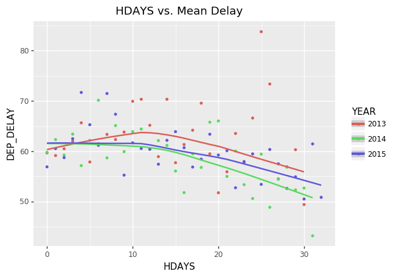

```python
(p9.ggplot(H_delay, p9.aes(x='HDAYS', y='DEP_DELAY',color='YEAR'))
 #+ p9.facet_wrap('YEAR')
 + p9.geoms.geom_point(size=1)
 + p9.stat_smooth()
 + p9.ggtitle('HDAYS vs. Mean Delay')
)
```

### 3.5.2 Delay Counts with HDAYS

```python
H_grp = nsfo.groupby(['YEAR','HDAYS'])
```

```python
d_count = H_grp.DELAY_FLAG.sum().reset_index()
d_count.rename(columns={"DELAY_FLAG":"COUNT"},inplace=True)
d_count.head()
```

|  | YEAR | HDAYS | COUNT |
| --- | --- | --- | --- |
| 0 | 2013 | 0 | 1205.0 |
| 1 | 2013 | 1 | 1828.0 |
| 2 | 2013 | 2 | 1460.0 |
| 3 | 2013 | 3 | 2026.0 |
| 4 | 2013 | 4 | 2161.0 |

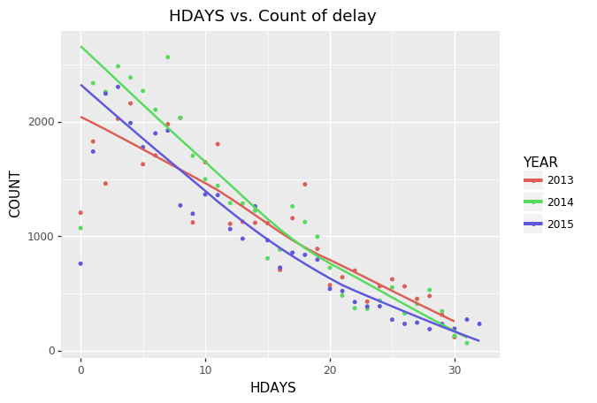

```python
(p9.ggplot(d_count, p9.aes(x='HDAYS', y='COUNT',color= 'factor(YEAR)'))
 + p9.geoms.geom_point(size=1)
 + p9.stat_smooth(se=False)
 + p9.labs(color = 'YEAR', title = 'HDAYS vs. Count of delay')
)
```

- **The counts of delay decrease as the day gets farther from a holiday, which indicates a high negative correlation between HDAYS and delay.**

### 3.5.3 Delay rate with HDAYS

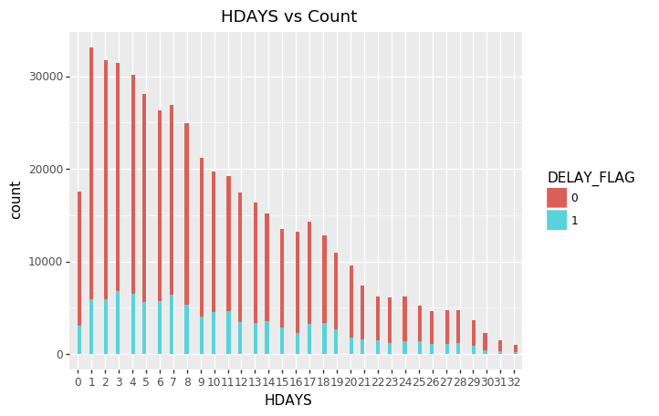

```python
(p9.ggplot(nsfo[['HDAYS','DELAY_FLAG']].dropna(axis=0))
 + p9.aes(x = 'HDAYS',fill = 'factor(DELAY_FLAG)')
 + p9.geom_histogram()\
 + p9.labs(fill='DELAY_FLAG',title = 'HDAYS vs Count')
)
```

- **As HDAYS increases, number of flights decrease, which makes sense because more people tend to go traveling during holidays.**

## 3.6 Weather Statistics and Visualization

### 3.6.1 Delay counts with WEATHER

```python
d_weather = full_df.groupby(['YEAR','WEATHER'])['DELAY_FLAG'].sum()
d_weather = d_weather.to_frame().reset_index().rename(columns={'DELAY_FLAG':'COUNT'})
d_weather.WEATHER = d_weather.WEATHER.map({1:'normal',2:'bad',3:'terrible'})
d_weather
```

|  | YEAR | WEATHER | COUNT |
| --- | --- | --- | --- |
| 0 | 2013 | normal | 18663.0 |
| 1 | 2013 | bad | 9588.0 |
| 2 | 2013 | terrible | 6461.0 |
| 3 | 2014 | normal | 19242.0 |
| 4 | 2014 | bad | 13636.0 |
| 5 | 2014 | terrible | 4877.0 |
| 6 | 2015 | normal | 12780.0 |
| 7 | 2015 | bad | 12267.0 |
| 8 | 2015 | terrible | 6376.0 |

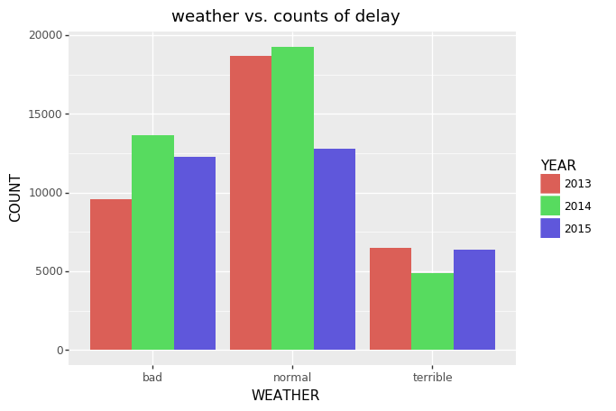

```python
(p9.ggplot(d_weather, p9.aes(x='WEATHER', y='COUNT',fill= 'YEAR'))
 + p9.geoms.geom_bar(stat='identity', position='dodge', show_legend=True)
 + p9.ggtitle('weather vs. counts of delay')
)
```

### 3.6.2 Delay rate with WEATHER

```python
d_weather_grp = full_df.groupby(['YEAR','WEATHER'])
d_ratio = (d_weather_grp['DELAY_FLAG'].sum()/d_weather_grp['DELAY_FLAG'].count()).reset_index()
d_ratio.rename(columns={"DELAY_FLAG":"RATIO"},inplace=True)
d_ratio.WEATHER = d_ratio.WEATHER.map({1:'normal',2:'bad',3:'terrible'})
d_ratio
```

|  | YEAR | WEATHER | RATIO |
| --- | --- | --- | --- |
| 0 | 2013 | normal | 0.195660 |
| 1 | 2013 | bad | 0.232324 |
| 2 | 2013 | terrible | 0.229227 |
| 3 | 2014 | normal | 0.197346 |
| 4 | 2014 | bad | 0.271185 |
| 5 | 2014 | terrible | 0.326592 |
| 6 | 2015 | normal | 0.175016 |
| 7 | 2015 | bad | 0.221822 |
| 8 | 2015 | terrible | 0.200851 |

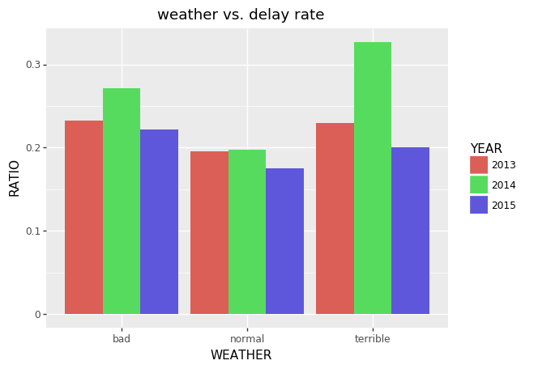

```python
(p9.ggplot(d_ratio, p9.aes(x='WEATHER', y='RATIO',fill= 'YEAR'))
 + p9.geom_bar(stat='identity', position='dodge', show_legend=True)
 + p9.labs(color = 'YEAR', title = 'weather vs. delay rate')
)
```

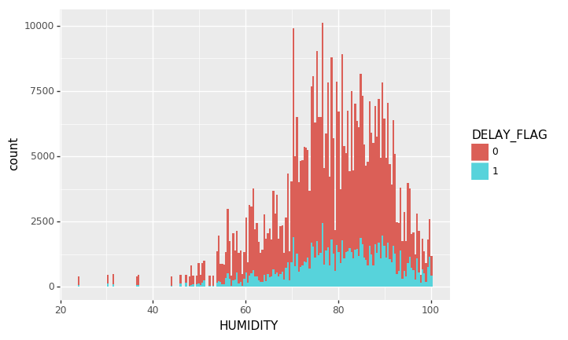

```python
(p9.ggplot(full_df[['HUMIDITY','DELAY_FLAG']].dropna(axis=0))
 + p9.aes(x = 'HUMIDITY',fill = 'factor(DELAY_FLAG)')
 + p9.geom_histogram()
 + p9.labs(fill='DELAY_FLAG')
)
```

- **The histogram shows left skewed distribution. Most flights concentrate in 70-95 interval.**

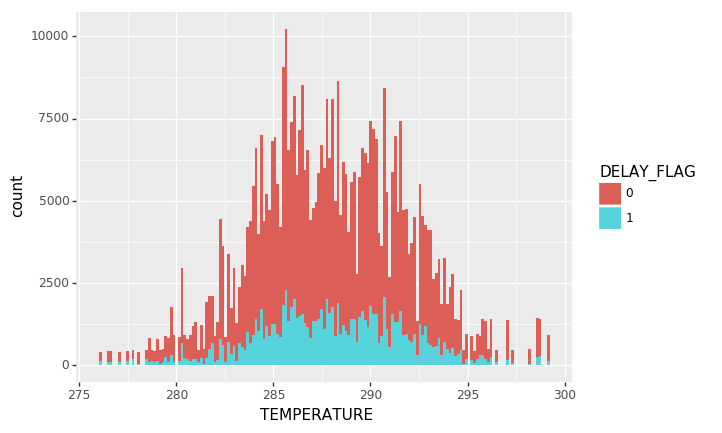

```python
(p9.ggplot(full_df[['TEMPERATURE','DELAY_FLAG']].dropna(axis=0))
 + p9.aes(x = 'TEMPERATURE',fill = 'factor(DELAY_FLAG)')
 + p9.geom_histogram()
 + p9.labs(fill='DELAY_FLAG')
)
```

- **The histogram shows normal distribution. Most flights concentrate in 282.5-292.5 interval.**

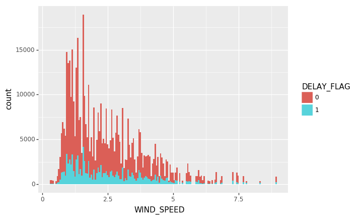

```python
(p9.ggplot(full_df[['WIND_SPEED','DELAY_FLAG']].dropna(axis=0))
 + p9.aes(x = 'WIND_SPEED',fill = 'factor(DELAY_FLAG)')
 + p9.geom_histogram()
 + p9.labs(fill='DELAY_FLAG')
)
```

- **The histogram shows right skewed distribution. Higher wind speed has less flights.**